# Лабораторная работы №4. Работа с программными пакетами.

Презентация

Глушенок А. А.

Российский университет дружбы народов, Москва, Россия

06 сентября 2025

## Докладчик

- Глушенок Анна Александровна
- Студент НПИбд-01-24
- Факультет физико-математических и естественных наук
- Российский университет дружбы народов
- 1132246844@pfur.ru
- https://github.com/aaglushenok

## Цель работы

Получить навыки работы с репозиториями и менеджерами пакетов.

## Работа с репозиториями

1. В консоли перейдите в режим работы суперпользователя.
2. Перейдите в каталог /etc/yum.repos.d и изучите содержание каталога и файлов репозиториев.

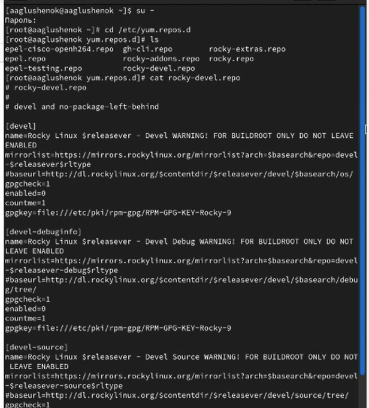

Задания 1-2

## Работа с репозиториями

3. Выведите на экран список репозиториев.

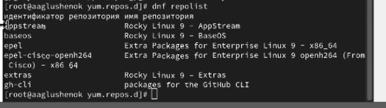

Задание 3

## Работа с репозиториями

4. Выведите на экран список пакетов, в названии или описании которых есть слово user.

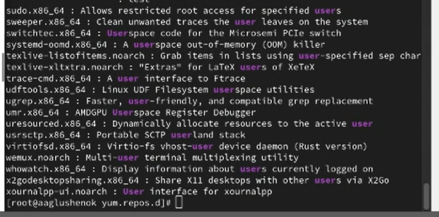

## Работа с репозиториями

5. Установите nmap, предварительно изучив информацию по имеющимся пакетам.

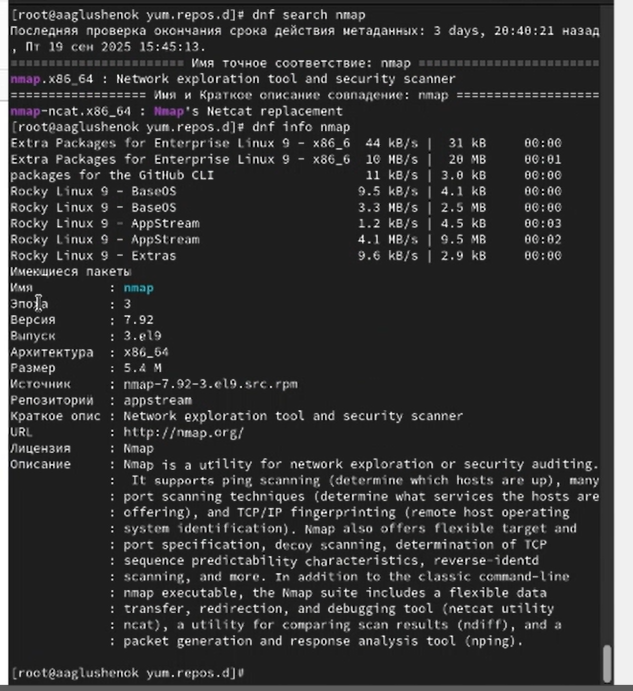

Задание 5(2)

## Работа с репозиториями

[figure not shown]

Задание 5(1)

## Работа с репозиториями

6. Удалите nmap.

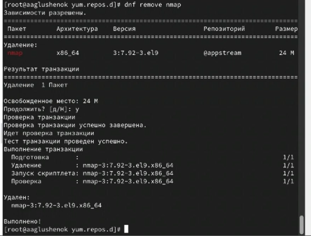

Задание 6(1)

## Работа с репозиториями

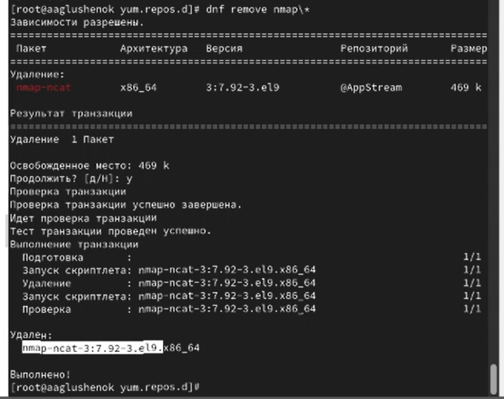

Задание 6(2)

## Работа с репозиториями

7. Получите список имеющихся групп пакетов, затем установите группу пакетов RPM Development Tools. Для удаления группы пакетов RPM Development Tools можно воспользоваться командой dnf groupremove “RPM Development Tools”.

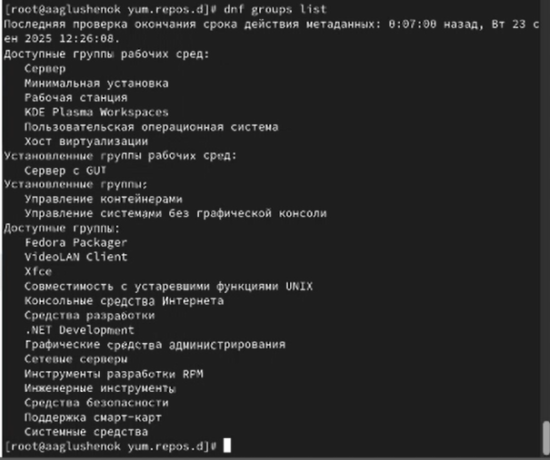

Задание 7(1)

## Работа с репозиториями

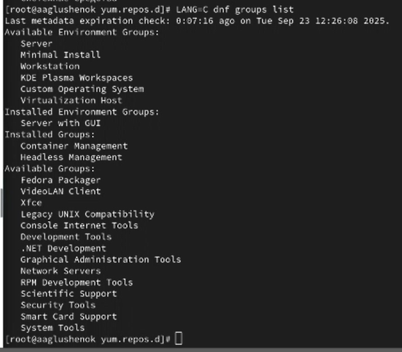

Задание 7(2)

## Работа с репозиториями

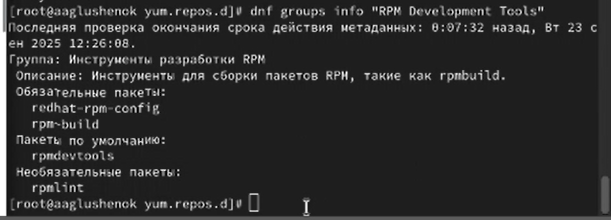

Задание 7(3)

## Работа с репозиториями

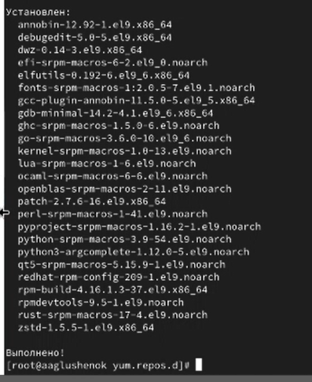

Задание 7(4)

## Работа с репозиториями

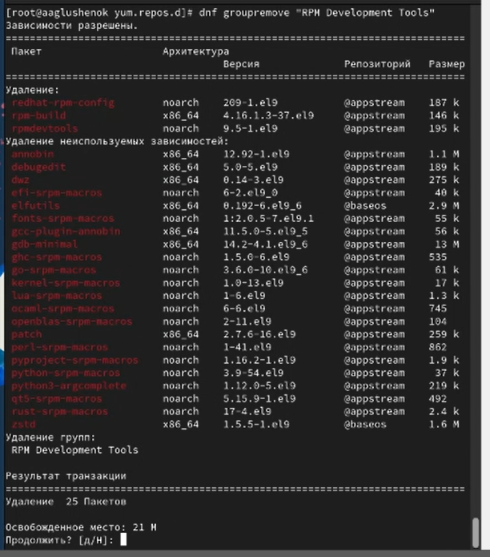

Задание 7(5)

## Работа с репозиториями

8. Посмотрите историю использования команды dnf. Отмените последнее действие.

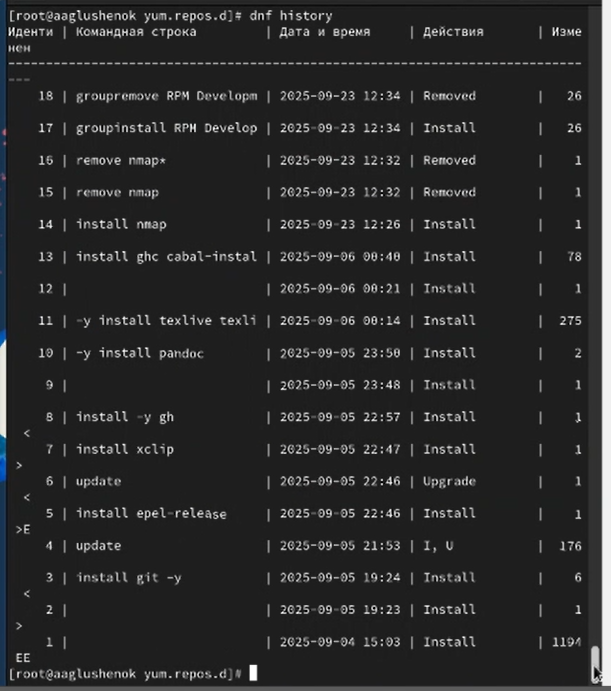

Задание 8(1)

## Работа с репозиториями

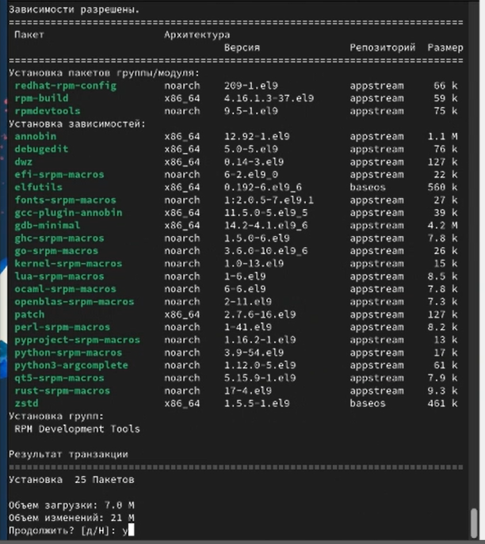

Задание 8(3)

## Использование rpm

Предположим, что требуется установить текстовый браузер lynx из rpm-пакета.

1. Скачайте rpm-пакет lynx:

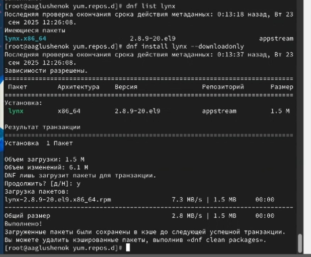

Задание 1

## Использование rpm

2. Найдите каталог, в который был помещён пакет после загрузки.
3. Перейдите в этот каталог и затем установите rpm-пакет.
4. Определите расположение исполняемого файла.

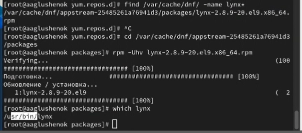

Задания 2-4

## Использование rpm

5. Используя rpm, определите по имени файла, к какому пакету принадлежит lynx. Получите дополнительную информацию о содержимом пакета.

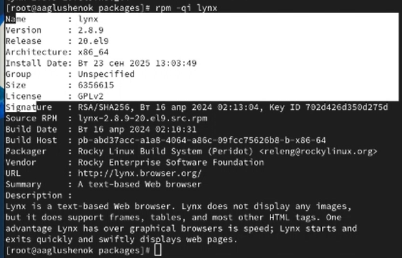

Задание 5

## Использование rpm

6. Получите список всех файлов в пакете, используя. А так же выведите перечень файлов с документацией пакета. Посмотрите файлы документации, применив команду man lynx.

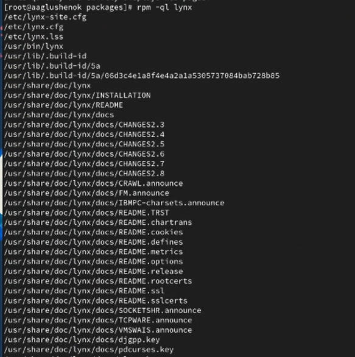

Задание 6(1)

## Использование rpm

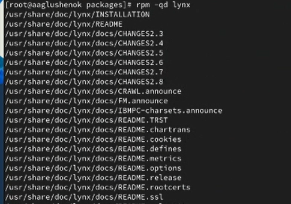

Задание 6(2)

## Использование rpm

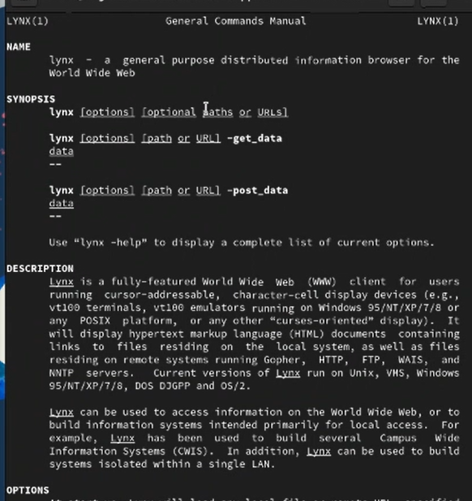

Задание 6(3)

## Использование rpm

7. Выведите на экран перечень и месторасположение конфигурационных файлов пакета.
8. Выведите на экран расположение и содержание скриптов, выполняемых при установке пакета.

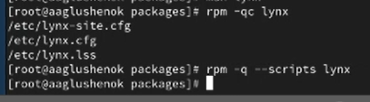

Задания 7-8

## Использование rpm

9. В отдельном терминале под своей учётной записью запустите текстовый браузер lynx, чтобы проверить корректность установки пакета.

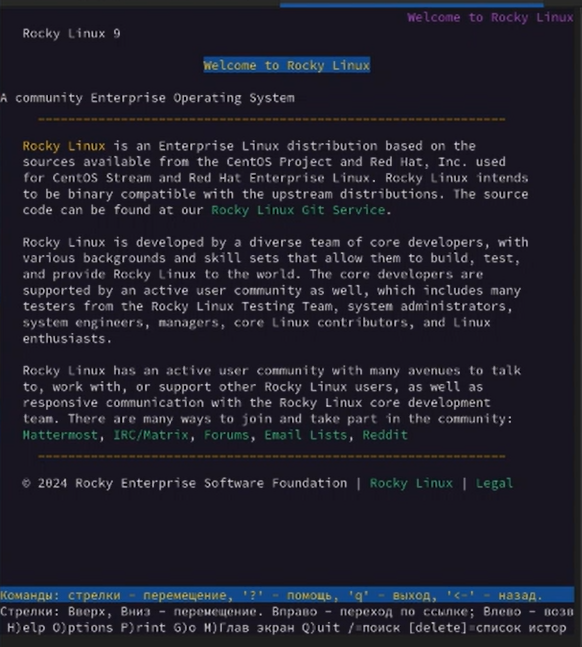

Задание 9

## Использование rpm

10. Вернитесь в терминал с учётной записью root и удалите пакет.

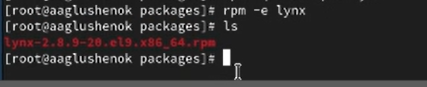

Задание 10

## Использование rpm

Предположим, что требуется из rpm-пакетов установить dnsmasq (DNS-, DHCP- и TFTP- сервер).

1. Установите пакет dnsmasq.

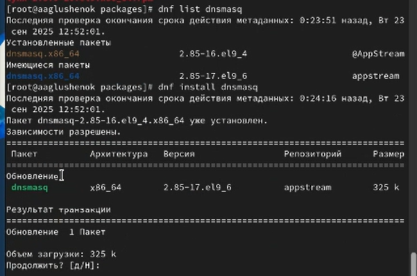

Задание 1

## Использование rpm

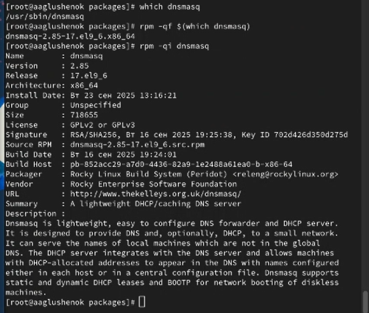

Задание 2

## Использование rpm

3. Получите список всех файлов в пакете. А также выведите перечень файлов с документацией пакета. Посмотрите файлы документации, применив команду man dnsmasq.

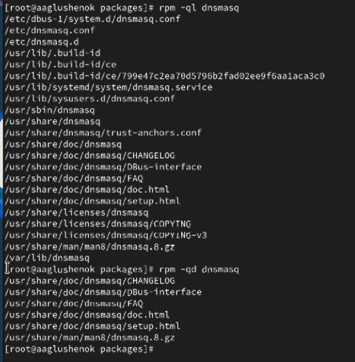

Задание 3(1)

## Использование rpm

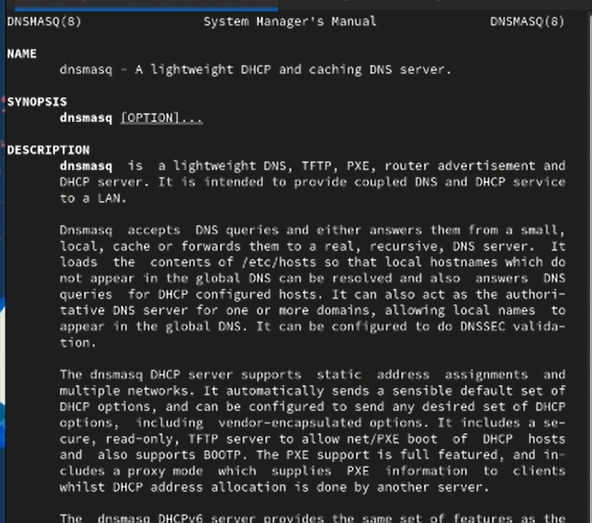

Задание 3(2)

## Использование rpm

4. Выведите на экран перечень и месторасположение конфигурационных файлов пакета.
5. Выведите на экран расположение и содержание скриптов, выполняемых при установке пакета.

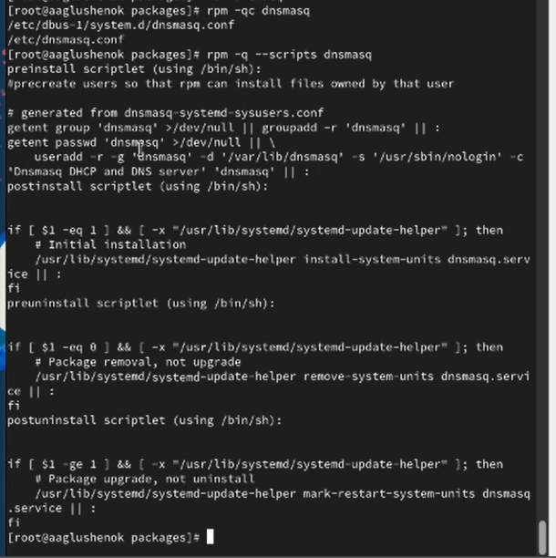

Задания 4-5

## Использование rpm

6. Вернитесь в терминал с учётной записью root и удалите пакет dnsmasq.

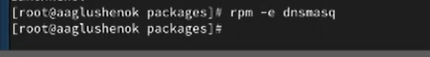

Задание 6

## Выводы

В ходе выполнения лабораторной работы №4 мне удалось получить навыки работы с репозиториями и менеджерами пакетов.

## Благодарю за внимание!